# Taylor Swift is Goated

Author

Kelson Jensen, Brady Heinig, Riley Williams, Summer Price

## Import

```r
library(tidyverse)
tuesdata <- tidytuesdayR::tt_load('2023-10-17')
taylor_album_songs <- tuesdata$taylor_album_songs
taylor_all_songs <- tuesdata$taylor_all_songs
taylor_albums <- tuesdata$taylor_albums
```

We used python packages in order to web scrape the necessary information for this project. That file can be found [here](https://github.com/brady-heinig/tswift/blob/main/tswift_scrape.ipynb)

## Tidy

```r
all <- left_join(taylor_album_songs, taylor_albums, taylor_all_songs, by="album_name")
View(all)
```

## Transform

```r
#created a new data set mutating categorical variables to be either true or false arguments
all.new <-all |>
select(track_name, album_name, album_release.x, duration_ms, acousticness,energy,danceability, explicit, featuring)|>
mutate(explicit = as.logical(explicit))|>
mutate(featuring = !is.na(featuring))
View(all.new)
#Web scraped data set and merge two data sets
TaylorTidyData2 <- read.csv("TaylorTidyData2.csv")
swiftstreams <- read.csv("swiftstreams.csv")
#Merge the two tables together
final_table <- merge(TaylorTidyData2, swiftstreams, by.x = "track_name", by.y = "Song.Name", all = FALSE)
#Rename columns to match r best practice
names(final_table)[names(final_table) == "Total.Streams"] <- "total_streams"
names(final_table)[names(final_table) == "Daily.Streams"] <- "daily_streams"
#Make stream columns into numeric
final_table <- final_table  |>
mutate(total_streams = as.numeric(gsub(",","",total_streams))) |>
mutate(daily_streams = as.numeric(gsub(",","",daily_streams)))
final_dataset <- final_table[order(-final_table$total_streams), ]
```

## Visualize

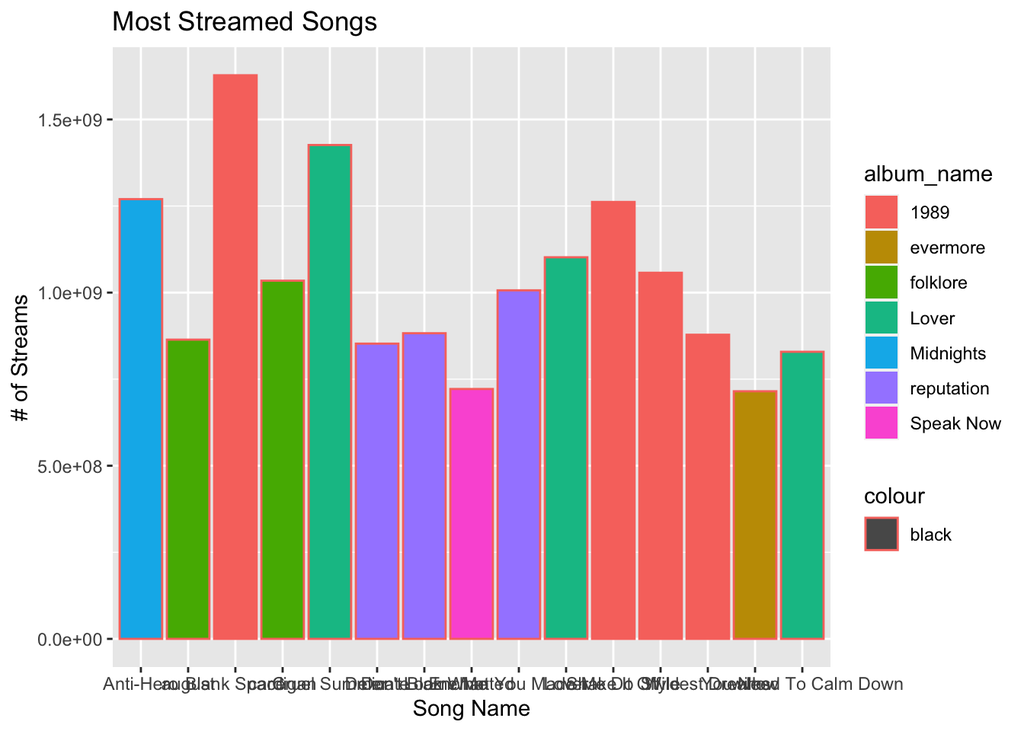

```r
library(ggplot2)
swift <- final_dataset
swift20 <- head(swift, 15)
ggplot(swift20, aes(x=track_name, y = total_streams, color= "black", fill = album_name))+
  geom_bar(stat="identity")+
  labs(x = "Song Name",
       y= "# of Streams",
       title = "Most Streamed Songs")
```

This is a simple graph that shows what songs are the most popular. The interesting part about this graph is the number of the top 15 songs that are from the 1989 album. 4/15 of the songs are from the album 1989. There are two other albums with three songs in the top 15 but no other albums have 4.

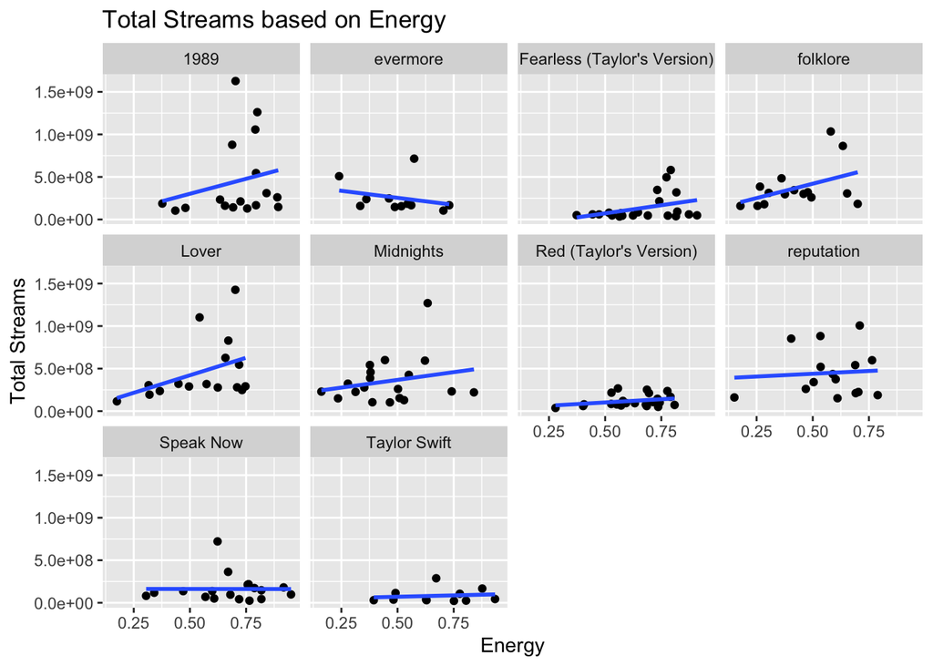

```r
ggplot(swift, aes(x = energy, y = total_streams)) +
  geom_point() +
  geom_smooth(method = "lm", se = FALSE) +
  facet_wrap(~album_name) +
  labs(
    y = "Total Streams",
    x = "Energy",
    title = "Total Streams based on Energy"
  )
```

Looking at this graph we can see a few things. One is that there is a small correlation based on higher energy there is more total streams. This being said there is such a small correlation in the majority of albums, however, there are some albums where this holds true to a greater extent such as the album “Lover.”

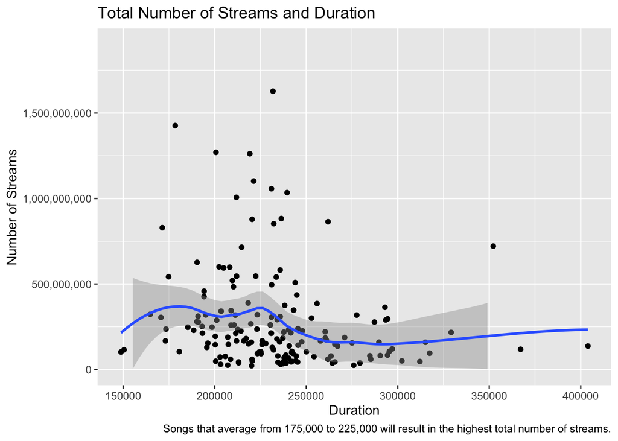

```r
##Duration and total number of streams plot
ggplot(swift, aes(x = duration_ms, y = total_streams)) +
  geom_point() +
  geom_smooth(method = "loess", formula = y ~ x, span = 0.6) +
  scale_y_continuous(label = scales::comma, limits = c(0, 1900000000)) +
  labs(x = "Duration",
       y = "Number of Streams",
       title = "Total Number of Streams and Duration",
       caption="Songs that average from 175,000 to 225,000 will result in the highest total number of streams."
       )
```

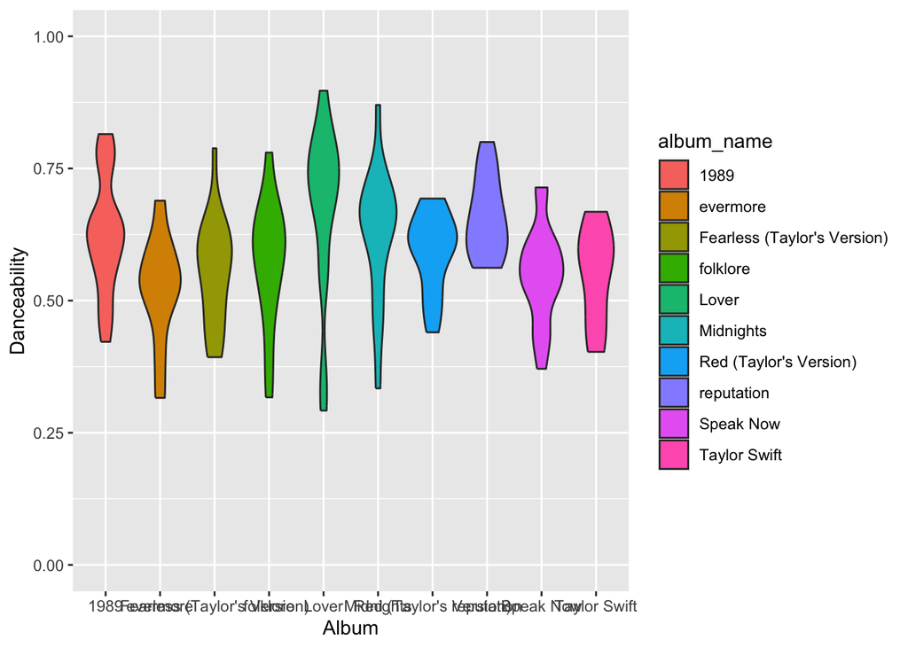

```r
##Violin with dance and popularity
library(tidyr)
library(dplyr)
ggplot(swift, aes(x=album_name, y=danceability, fill=album_name)) +
  geom_violin()+
scale_y_continuous(label = scales::comma, limits = c(0, 1))+
  labs(x="Album",
       y="Danceability",
       color = "Album Name")
```

[figure not shown]

```r
swift2 <- swift|>
  mutate(total_streams2 = total_streams/1000000)|>
  mutate(daily_streams2 = total_streams/1000000)

library(ggridges)
library(ggplot2)
library(viridis)
library(hrbrthemes)

# Plot
ggplot(swift2, aes(x = total_streams2, y = album_name, fill = ..y..)) +
  geom_density_ridges_gradient(scale = 3, rel_min_height = 0.01) +
  scale_fill_viridis(option = "H", alpha=.7) +
  labs(title = "Density of Total Streams by Album",
       x = "Total Streams in Millions",
       y= "Album Name") +
  theme_ipsum_pub()+
  theme(
    legend.position = "none",
    panel.spacing = unit(0.1, "lines"),
    strip.text.x = element_text(size = 8)+
      scale_x_continuous(labels = scales::comma_format(scale = 1))
  )
```

As we analyzed this graph, we saw that “Lover” was her most popular song because the median of popularity was the highest. We can also see that “1989” had the many songs with very high total streams We can infer that “1989” had some “one hit.

[figure not shown]

```r
swift |>
  ggplot(aes(x = danceability, y = acousticness, color = energy)) +
  geom_point() +
  labs(title = "Comparison of the Three Attributes",
       x = "Danceability",
       y = "Acousticness",
       color = "Energy") +
  scale_color_viridis(option = "E") +
  theme_ipsum_es()
```

While looking at the three attributes of Taylor Swift Songs, We found that only some of the variables are related. We can see that as acousticness goes up, Energy goes down. Also, We can see that danceability doesn’t have a huge effect on acousticness or Energy

## Model

```r
# Multiple Linear Regression Model
mlr.swift <- lm(total_streams ~ duration_ms + acousticness + energy + danceability + explicit + featuring, data=swift)
summary(mlr.swift)
```

```
Call:
lm(formula = total_streams ~ duration_ms + acousticness + energy +
    danceability + explicit + featuring, data = swift)

Residuals:
       Min         1Q     Median         3Q        Max
-296125032 -163392423  -89125706   57580642 1305898431

Coefficients:
               Estimate Std. Error t value Pr(>|t|)
(Intercept)   371939606  270160014   1.377   0.1705
duration_ms       -1145        618  -1.852   0.0658 .
acousticness  -17409900   98483373  -0.177   0.8599
energy         71419914  169230177   0.422   0.6736
danceability  219365149  212922116   1.030   0.3045
explicitTRUE   56734480   79741886   0.711   0.4778
featuringTRUE 159476001  288465004   0.553   0.5811
---
Signif. codes:  0 '***' 0.001 '**' 0.01 '*' 0.05 '.' 0.1 ' ' 1

Residual standard error: 286100000 on 159 degrees of freedom
  (1 observation deleted due to missingness)
Multiple R-squared:  0.04888,   Adjusted R-squared:  0.01299
F-statistic: 1.362 on 6 and 159 DF,  p-value: 0.2332
```

```r
# Model coefficients
coefficients(mlr.swift)
```

```
  (Intercept)   duration_ms  acousticness        energy  danceability
371939606.349     -1144.631 -17409899.462  71419913.788 219365149.197
 explicitTRUE featuringTRUE
 56734480.296 159476001.128
```

```r
# Anova of Model
anova(mlr.swift)
```

```
Analysis of Variance Table

Response: total_streams
              Df     Sum Sq    Mean Sq F value  Pr(>F)
duration_ms    1 4.6901e+17 4.6901e+17  5.7288 0.01785 *
acousticness   1 2.7923e+16 2.7923e+16  0.3411 0.56004
energy         1 1.7574e+15 1.7574e+15  0.0215 0.88370
danceability   1 1.0469e+17 1.0469e+17  1.2788 0.25983
explicit       1 4.0531e+16 4.0531e+16  0.4951 0.48270
featuring      1 2.5022e+16 2.5022e+16  0.3056 0.58115
Residuals    159 1.3017e+19 8.1868e+16
---
Signif. codes:  0 '***' 0.001 '**' 0.01 '*' 0.05 '.' 0.1 ' ' 1
```

The R^2 is extremely low for this model, meaning very little variability in total streams is explained by our explanatory variables.

Our explanatory variables appear to not have a linear relationship with total streams, meaning we should look at other methods to accurately predict future song success (Logistic Regression, etc.) We decided to perform an ANOVA to look at the different albums that Taylor Swift has produced and see if any particular album yielded higher streaming figures than others. We wanted to also study the explicitness of songs and if that had any impact on the popularity of the song.

```r
#Anova for comparing albums and explicitness of songs
aov.swift <- lm(total_streams ~ album_name + explicit, data=swift)
anova(aov.swift)
```

```
Analysis of Variance Table

Response: total_streams
            Df     Sum Sq    Mean Sq F value    Pr(>F)
album_name   9 3.3656e+18 3.7395e+17  5.6164 1.045e-06 ***
explicit     1 1.5116e+14 1.5116e+14  0.0023    0.9621
Residuals  155 1.0320e+19 6.6582e+16
---
Signif. codes:  0 '***' 0.001 '**' 0.01 '*' 0.05 '.' 0.1 ' ' 1
```

Because the p-value is significant, we concluded that the album a song released in is significant, but whether a song is explicit or not has no bearing on how popular it becomes.

## Communicate

**Limitations:**

When we performed our Multiple Linear Regression, we had an R^2 value 0f 0.04, which is extremely low. Because of that, we concluded that there wasn't much of a correlation between "danceability", "energy", "acousticness" and our streaming totals. Either that was the case, or there wasn't a linear relationship.

One other limitation that we had was that our data was not time series. This would be much more helpful for our analysis because we wouldn't have the lurking factor of albums being out for longer, thus getting more total streams. If the data was time series, we could have created a graph of popularity over time.

The are obviously various factors that explain a song’s popularity, but it is hard to quantify a catchy tune. One thing is for certain: Taylor Swift knows how to make hits, and she isn’t showing any signs of slowing down.